# Informe estadístico sobre la brecha laboral en cuestiones de género en Argentina (1982-2018)

Patricia Perrone y Marianela Pi

## Introducción

Los datos utilizados en este informe fueron tomados por el Banco Mundial sobre empleo/desempleo y género para algunos países de Latinoamérica y el Caribe, entre los años 1970 y 2018. Estos datos fueron provintos en formato de *data-frame* y contienen una cantidad de variables que aportan datos sobre el empleo/desempleo, tipo de empleo/actividad y legislación.

Para ajustar los datos al alcance de este análisis, se utilizarán sólo los datos de Argentina comprendidos entre los años 1982 y 2018, que es el período en donde Argentina relevó datos. Fuera de ese período no hay información disponible.

## Exploración de los datos

```r
# Código para cargar o leer los datos
# Filtramos por país (Argentina) y eliminamos las columnas de años que no tienen datos para simplificar el análisis

empleo_genero <- read.csv("datos/empleo_genero.csv") %>% filter(pais_region=="Argentina") %>% select(1,16:52)


# Transposición de los datos de la tabla
empleo_Arg <- pivot_longer(empleo_genero, cols=2:38, names_to = "Anio", values_to = "porcentaje")

# reemplazo los valores de los años por el número correspondiente
empleo_Arg$Anio <- str_replace(empleo_Arg$Anio, "X", "")

str(empleo_Arg)
```

```
## tibble [740 × 3] (S3: tbl_df/tbl/data.frame)
##  $ variable  : chr [1:740] "empleadoras_mujeres" "empleadoras_mujeres" "empleadoras_mujeres" "empleadoras_mujeres" ...
##  $ Anio      : chr [1:740] "1982" "1983" "1984" "1985" ...
##  $ porcentaje: num [1:740] NA NA NA NA NA ...
```

La tabla empleo_Arg contiene 3 variables y 740 observaciones. Los nombres de las variables son: Variable, Anio y porcentaje

### Desempleo

```r
# Comparación del desempleo por género, filtro variable por desempleo y agrego columna con el sexo
desempleo <- filter(empleo_Arg,variable %in% c("desempleo_mujeres","desempleo_hombres")) %>%
            mutate(sexo = ifelse(variable == "desempleo_mujeres","Mujer","Hombre"))

# Cálculo de estadísticos
mdesempleo <- desempleo %>% group_by(variable) %>% summarise(media = mean(porcentaje,na.rm = TRUE), desvio = sd(porcentaje,na.rm = TRUE), max = max(porcentaje,na.rm = TRUE), min = min(porcentaje,na.rm = TRUE), rango = max-min)
```

#### Valores estadísticos

```r
knitr::kable(mdesempleo)
```

| variable | media | desvio | max | min | rango |
| --- | --- | --- | --- | --- | --- |
| desempleo_hombres | 9.916752 | 4.630253 | 20.13 | 3.38 | 16.75 |
| desempleo_mujeres | 12.222180 | 5.191353 | 22.30 | 4.19 | 18.11 |

#### Cantidad de observaciones

```r
str(desempleo)
```

```
## tibble [74 × 4] (S3: tbl_df/tbl/data.frame)
##  $ variable  : chr [1:74] "desempleo_mujeres" "desempleo_mujeres" "desempleo_mujeres" "desempleo_mujeres" ...
##  $ Anio      : chr [1:74] "1982" "1983" "1984" "1985" ...
##  $ porcentaje: num [1:74] 5.4 4.8 4.19 NA NA ...
##  $ sexo      : chr [1:74] "Mujer" "Mujer" "Mujer" "Mujer" ...
```

El primer análisis que podemos hacer es comparar ciertos datos estadísticos con respecto a la desocupación. En la siguiente tabla se puede observar la diferencia entre los valores con un promedio del 12.22 para las mujeres y del 9.91 para los hombres. Dentro de los datos no se encontro ninguna alguna anomalía que sugiera que hay datos incorrectos o Valores imposibles

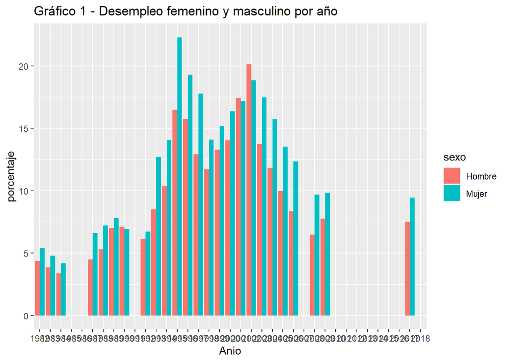

```r
ggplot(desempleo,aes(Anio,porcentaje, fill = sexo)) + geom_bar(stat = "Identity",position=position_dodge()) + labs(title = "Gráfico 1 - Desempleo femenino y masculino por año")
```

Incluso cuando se trata de hombres y mujeres con educacion terciaria, las diferencias sigue ahí

### Desempleo calificado

```r
# Comparación del desempleo por género, filtro variable por desempleo y agrego columna con el sexo
desempleo_calificado <- filter(empleo_Arg,variable %in% c("desempleo_educacion_mujeres","desempleo_educacion_hombres")) %>%
            mutate(sexo = ifelse(variable == "desempleo_educacion_mujeres","Mujer","Hombre"))

# Retiro los años sin datos para acrotar el gráfico
desempleo_calificado <- filter(desempleo_calificado, Anio > "2000")
```

#### Valores estadísticos

```r
# Cálculo de estadísticos desempleo calificado
mdescal <- desempleo_calificado %>% group_by(variable) %>% summarise(media = mean(porcentaje,na.rm = TRUE), desvio = sd(porcentaje,na.rm = TRUE), max = max(porcentaje,na.rm = TRUE), min = min(porcentaje,na.rm = TRUE), rango = max-min)

knitr::kable(mdescal)
```

| variable | media | desvio | max | min | rango |
| --- | --- | --- | --- | --- | --- |
| desempleo_educacion_hombres | 4.100385 | 3.333397 | 12.99 | 1.8024 | 11.1876 |
| desempleo_educacion_mujeres | 5.916315 | 3.739132 | 14.50 | 3.5257 | 10.9743 |

#### Cantidad de observaciones en desempleo calificado

```r
str(desempleo_calificado)
```

```
## tibble [36 × 4] (S3: tbl_df/tbl/data.frame)
##  $ variable  : chr [1:36] "desempleo_educacion_mujeres" "desempleo_educacion_mujeres" "desempleo_educacion_mujeres" "desempleo_educacion_mujeres" ...
##  $ Anio      : chr [1:36] "2001" "2002" "2003" "2004" ...
##  $ porcentaje: num [1:36] NA 14.5 13.69 6.75 5.66 ...
##  $ sexo      : chr [1:36] "Mujer" "Mujer" "Mujer" "Mujer" ...
```

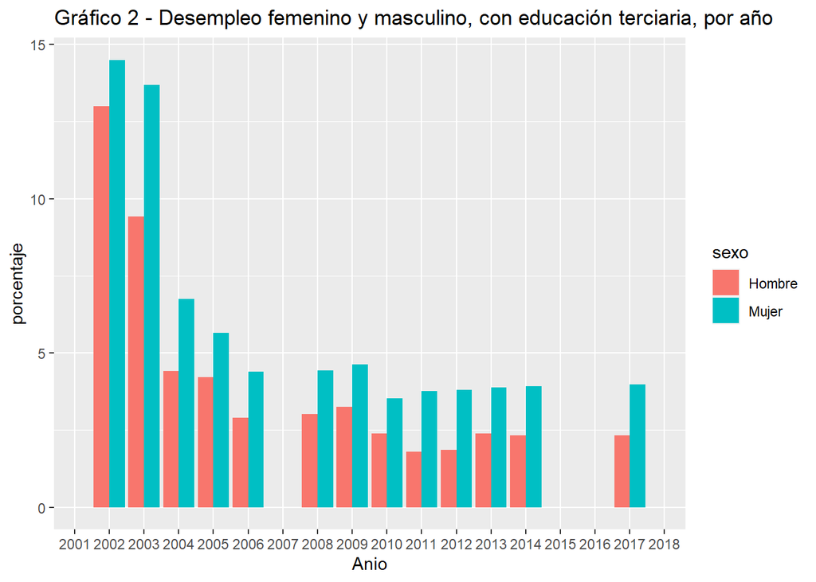

```r
ggplot(desempleo_calificado,aes(Anio,porcentaje, fill = sexo,na.rm = TRUE)) + geom_bar(stat = "Identity",position=position_dodge()) + labs(title = "Gráfico 2 - Desempleo femenino y masculino, con educación terciaria, por año")
```

La población de mujeres con nivel terciario desempleadas ha alcanzado el 5.91%, mientras que los varones alcanzaron el 4.10%. Si bien las credenciales educativas de las mujeres parecieran favorecer su participación en el mercado de trabajo, cuando analizamos los datos como mujeres trabajadoras se evidencia una situación de desventaja para ellas.

### Tipos de actividad

```r
# Armo una tabla por tipo de empleo y agrego la columna sexo igual que en desempleo

tipo_empleo <- filter(empleo_Arg,variable %in% c("empleo_agricultura_mujeres","empleo_agricultura_hombres","empleo_industria_mujeres","empleo_industria_hombres","empleo_servicios_mujeres","empleo_servicios_hombres","empleo_informal_mujeres","empleo_informal_hombres","autoempleo_mujeres","autoempleo_hombres")) %>%
               mutate(sexo = ifelse(str_detect(variable,"mujeres"),"Mujer","Hombre")) %>%
               mutate(tipo = substring(variable,8,str_length(variable)-8))

# Corrijo el "autoempleo"
tipo_empleo$tipo <- str_replace(tipo_empleo$tipo, "leo", "autoempleo")
```

#### Valores estadísticos de tipo de actividad

```r
# Cálculo de estadísticos desempleo calificado
mtempleo <- tipo_empleo %>% group_by(variable) %>% summarise(media = mean(porcentaje,na.rm = TRUE), desvio = sd(porcentaje,na.rm = TRUE), max = max(porcentaje,na.rm = TRUE), min = min(porcentaje,na.rm = TRUE), rango = max-min)

knitr::kable(mtempleo)
```

| variable | media | desvio | max | min | rango |
| --- | --- | --- | --- | --- | --- |
| autoempleo_hombres | 22.7365358 | 1.6157118 | 27.032 | 19.944 | 7.087999 |
| autoempleo_mujeres | 18.2403571 | 2.8329900 | 24.725 | 14.876 | 9.849000 |
| empleo_agricultura_hombres | 1.0274286 | 0.5492398 | 1.874 | 0.089 | 1.785000 |
| empleo_agricultura_mujeres | 0.3238571 | 0.2375489 | 0.974 | 0.015 | 0.959000 |
| empleo_industria_hombres | 33.5816071 | 3.0512160 | 41.123 | 27.905 | 13.218000 |
| empleo_industria_mujeres | 11.2580716 | 2.9704226 | 19.767 | 8.326 | 11.441000 |
| empleo_informal_hombres | 49.8754546 | 3.7797895 | 57.320 | 46.880 | 10.439999 |
| empleo_informal_mujeres | 51.6872725 | 5.6045263 | 62.050 | 46.470 | 15.579998 |
| empleo_servicios_hombres | 65.3908928 | 2.8452150 | 70.749 | 58.405 | 12.344002 |
| empleo_servicios_mujeres | 88.4180355 | 2.9851998 | 91.520 | 80.097 | 11.422996 |

#### Cantidad de observaciones en tipo de empleo

```r
str(tipo_empleo)
```

```
## tibble [370 × 5] (S3: tbl_df/tbl/data.frame)
##  $ variable  : chr [1:370] "empleo_agricultura_mujeres" "empleo_agricultura_mujeres" "empleo_agricultura_mujeres" "empleo_agricultura_mujeres" ...
##  $ Anio      : chr [1:370] "1982" "1983" "1984" "1985" ...
##  $ porcentaje: num [1:370] NA NA NA NA NA ...
##  $ sexo      : chr [1:370] "Mujer" "Mujer" "Mujer" "Mujer" ...
##  $ tipo      : chr [1:370] "agricultura" "agricultura" "agricultura" "agricultura" ...
```

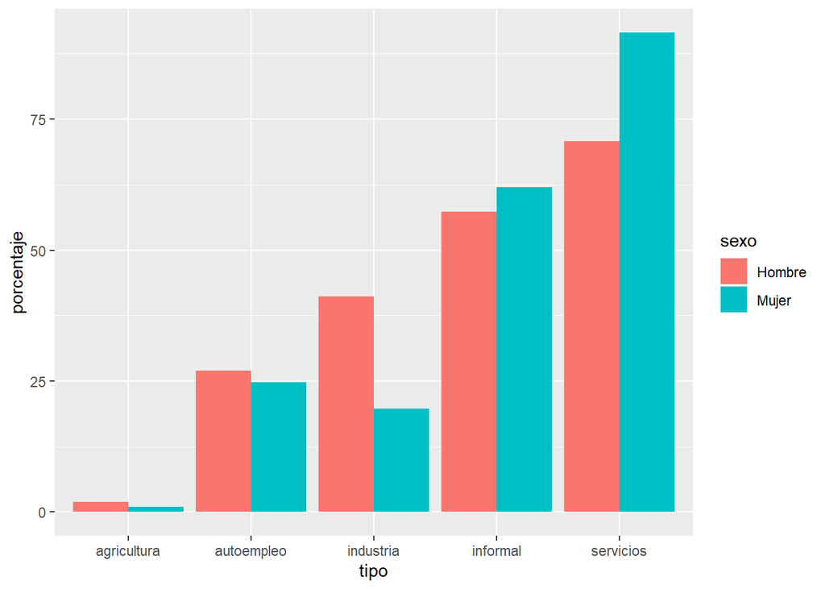

```r
# Grafico por tipo de actividad
ggplot(tipo_empleo,aes(tipo,porcentaje, fill = sexo)) + geom_bar(stat = "Identity",position=position_dodge())
```

### Empleo domestico

```r
empleo_domestico <- filter(empleo_Arg,variable %in% c("trabajo_domestico_no_remunerado_mujeres","trabajo_domestico_no_remunerado_hombres")) %>%
                    mutate(sexo = ifelse(variable == "trabajo_domestico_no_remunerado_mujeres","Mujer","Hombre"))

# Retiro los años sin datos para acrotar el gráfico
empleo_domestico <- filter(empleo_domestico, Anio > "2003")
```

#### Valores estadísticos de tipo de actividad

```r
medomestico <- empleo_domestico %>% group_by(variable) %>% summarise(media = mean(porcentaje,na.rm = TRUE), desvio = sd(porcentaje,na.rm = TRUE), max = max(porcentaje,na.rm = TRUE), min = min(porcentaje,na.rm = TRUE), rango = max-min)

knitr::kable(medomestico)
```

| variable | media | desvio | max | min | rango |
| --- | --- | --- | --- | --- | --- |
| trabajo_domestico_no_remunerado_hombres | 7.318978 | 1.688686 | 9.248601 | 6.111111 | 3.137490 |
| trabajo_domestico_no_remunerado_mujeres | 19.218250 | 3.657641 | 23.418640 | 16.736111 | 6.682529 |

#### Cantidad de observaciones en tipo de empleo

```r
str(empleo_domestico)
```

```
## tibble [30 × 4] (S3: tbl_df/tbl/data.frame)
##  $ variable  : chr [1:30] "trabajo_domestico_no_remunerado_mujeres" "trabajo_domestico_no_remunerado_mujeres" "trabajo_domestico_no_remunerado_mujeres" "trabajo_domestico_no_remunerado_mujeres" ...
##  $ Anio      : chr [1:30] "2004" "2005" "2006" "2007" ...
##  $ porcentaje: num [1:30] NA 16.7 NA NA NA ...
##  $ sexo      : chr [1:30] "Mujer" "Mujer" "Mujer" "Mujer" ...
```

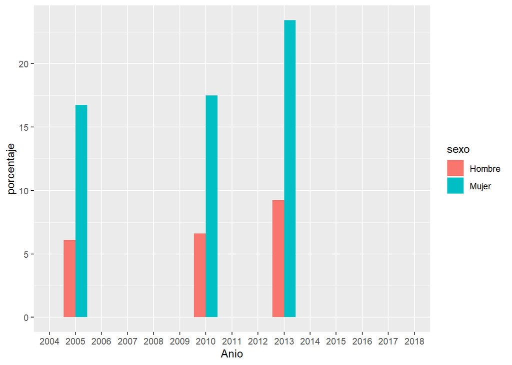

```r
ggplot(empleo_domestico,aes(Anio,porcentaje, fill = sexo)) + geom_bar(stat = "Identity",position=position_dodge())
```

Es imposible imaginar un mundo en el cual no exista quien realice las tareas cotidianas de la vida, como alimentar a un/a bebé, limpiar la casa o hacer las compras. Lamentablemente es una tarea que se asocia al rol femenino y actuamente sigue habiendo una brecha muy marcada donde en los datos estadísticos la media nos muestra 19.21 para las mujeres y 7.31 para los hombres.

## Hipótesis

La igualdad de género es un derecho fundamental y crucial para el desarrollo sostenible, sin embargo aún se observan marcadas diferencias entre mujeres y hombres en los mercados de trabajo de todos los países del mundo. Algunas de las preguntas que nos hacemos son las siguientes:**¿Existe una brecha de desempleo de acuerdo al género de las personas?, ¿Las mujeres con el mismo nivel academico que los hombres tienen las mismas oportunidades de ocupar un puesto jerárquico?, ¿y cuando hablamos de cargos jerárquicos?, ¿qué tanta diferencia hay entre los ingresos de los hombres y de las mujeres?, ¿Los trabajos domesticos le resta tiempo para realizar trabajo remunerado a las mujeres?, ¿Esta asociado el trabajo domestico con el trabajo informal? ¿Las mujeres pueden desarrolarse en cualquier tipo de empleo o el sistema las condiciona a realizar determinadas tareas?**.